# Manipulating data

9/4/2020

## data usually does not come with a bow on top

- almost all real world data won’t be ready for plotting; usually steps to *clean* and *tidy* the data are required
- clean data as all the data with the right data types, IE numbers are `numeric`, strings are `characters`
- tidy data has data organized such that each complete row is a unique observation.
- thankfully there are quite a bit of resources for doing this within R

## the Tidyverse

- the tidyverse is a collection of packages that provide *fast, well documented* functions for data science.
- This includes reading and writing data, organizing and “tidying” data, and plotting data

```r
library(tidyverse)
```

## the `readr` package

- easiest to use, this is for reading external data *into* R, and writing data within R *to* the disk;

## reading data

- generally tabular data is arranges where each element within a row is separated by a delimiter, and whole rows are separated by a newline
- the delimiter are commonly tabs `\t`, or commas, `,`. The delimiter is reflected in the file extensions of tabular data, IE “tab separated values” is a `.tsv` file, and "comma separated values are `.csv`
- the `read_...` functions all work the same way - just provide the name of the file

## reading data

```r
data <- read_tsv('dummy.tsv')
data
```

```
## # A tibble: 6 × 11
##     mpg   cyl  disp    hp  drat    wt  qsec    vs    am  gear  carb
##   <dbl> <dbl> <dbl> <dbl> <dbl> <dbl> <dbl> <dbl> <dbl> <dbl> <dbl>
## 1  21       6   160   110  3.9   2.62  16.5     0     1     4     4
## 2  21       6   160   110  3.9   2.88  17.0     0     1     4     4
## 3  22.8     4   108    93  3.85  2.32  18.6     1     1     4     1
## 4  21.4     6   258   110  3.08  3.22  19.4     1     0     3     1
## 5  18.7     8   360   175  3.15  3.44  17.0     0     0     3     2
## 6  18.1     6   225   105  2.76  3.46  20.2     1     0     3     1
```

## reading data

```r
data <- read_csv('dummy.csv')
data
```

```
## # A tibble: 6 × 5
##   Sepal.Length Sepal.Width Petal.Length Petal.Width Species
##          <dbl>       <dbl>        <dbl>       <dbl> <chr>
## 1          5.1         3.5          1.4         0.2 setosa
## 2          4.9         3            1.4         0.2 setosa
## 3          4.7         3.2          1.3         0.2 setosa
## 4          4.6         3.1          1.5         0.2 setosa
## 5          5           3.6          1.4         0.2 setosa
## 6          5.4         3.9          1.7         0.4 setosa
```

## writing data

- writing data works similarly to reading it; just provides a `tibble` and a filename to write to

```r
write_tsv(head(mtcars), path =  'dummy.tsv')
write_csv(head(iris), path = 'dummy.csv')
write_delim(head(airquality) ,'dummy.txt', delim ='|')
```

## reading data

- use read_delim to use a custom delimiter

```r
data <- read_delim('dummy.txt', delim = '|')
data
```

```
## # A tibble: 6 × 6
##   Ozone Solar.R  Wind  Temp Month   Day
##   <dbl>   <dbl> <dbl> <dbl> <dbl> <dbl>
## 1    41     190   7.4    67     5     1
## 2    36     118   8      72     5     2
## 3    12     149  12.6    74     5     3
## 4    18     313  11.5    62     5     4
## 5    NA      NA  14.3    56     5     5
## 6    28      NA  14.9    66     5     6
```

## the filesystem

- In all computers are arranged as a series of nested folders, with files in each folder.
- the location of a file on your computer is called its `path`

## file paths

- This is an absolute file path `/Users/swamyvs/personal/BIOF076-Visualization-with-R/Using-The-Tidyverse`
- All paths start with ‘/’ on unix(macOS/linux) systems.
- On Windows, absolute paths always start with the drive name: `C:/User/local...`
- No matter where you are, absolute paths always point to the same location

## the working directory

- the working directory is the location on your computer that R looks for files in, or writes files too.
- your can find the working directory using the `getwd` function

```r
getwd()
```

```
## [1] "/Users/swamyvs/personal/BIOF076-Visualization-with-R/Using-The-Tidyverse"
```

## the working directory

```r
setwd('/Users/swamyvs/')
```

## the working directory

- use the `dir` function to show what files and folders are in the the working directory

```r
setwd("/Users/swamyvs/personal/BIOF076-Visualization-with-R/Using-The-Tidyverse/")
dir()
```

```
## [1] "dummy.csv"
## [2] "dummy.tsv"
## [3] "dummy.txt"
## [4] "intro_to_tidyverse_exercises.nb.html"
## [5] "intro_to_tidyverse_exercises.Rmd"
## [6] "intro_to_tidyverse_slides.html"
## [7] "intro_to_tidyverse_slides.Rmd"
```

## local filepaths

- files paths don’t have to absolute

```r
getwd()
```

```
## [1] "/Users/swamyvs/personal/BIOF076-Visualization-with-R/Using-The-Tidyverse"
```

## local filepaths

```r
setwd('../')
read_csv('Using-The-Tidyverse/dummy.csv')
```

```
## # A tibble: 6 × 5
##   Sepal.Length Sepal.Width Petal.Length Petal.Width Species
##          <dbl>       <dbl>        <dbl>       <dbl> <chr>
## 1          5.1         3.5          1.4         0.2 setosa
## 2          4.9         3            1.4         0.2 setosa
## 3          4.7         3.2          1.3         0.2 setosa
## 4          4.6         3.1          1.5         0.2 setosa
## 5          5           3.6          1.4         0.2 setosa
## 6          5.4         3.9          1.7         0.4 setosa
```

## working directorys in notebooks

- The working directory for a notebook is fixed to what every folder the notebook is saved in.
- If you change the working directory within a notebook cell, it applies *only* to that cell.

## filepaths summary

- always be careful of your filepaths; whenever possible use the absolute paths.
- When typing a file path in Rstudio, use `tab` to autocomplete the paths.

## the `tibble`

- `tibble` is a play on the word “table”
- the is the tidyverse’s reimplimentation of a data frame
- the key differences are that tibbles don’t have rownames, and that tibbles always maintain strings as `characters`

## the `tibble`

- `tibbles` are also a little easier to print out

```r
tibble(iris)
```

```
## # A tibble: 150 × 5
##    Sepal.Length Sepal.Width Petal.Length Petal.Width Species
##           <dbl>       <dbl>        <dbl>       <dbl> <fct>
##  1          5.1         3.5          1.4         0.2 setosa
##  2          4.9         3            1.4         0.2 setosa
##  3          4.7         3.2          1.3         0.2 setosa
##  4          4.6         3.1          1.5         0.2 setosa
##  5          5           3.6          1.4         0.2 setosa
##  6          5.4         3.9          1.7         0.4 setosa
##  7          4.6         3.4          1.4         0.3 setosa
##  8          5           3.4          1.5         0.2 setosa
##  9          4.4         2.9          1.4         0.2 setosa
## 10          4.9         3.1          1.5         0.1 setosa
## # … with 140 more rows
```

## the `tibble` package

- only a the first 10 or so rows are printed out, not all columns are printed out either

## the `tibble`

- use `tibble` just like `data.frame`

```r
tb <- tibble(x=rnorm(100), y=rnorm(100) )
head(tb)
```

```
## # A tibble: 6 × 2
##         x       y
##     <dbl>   <dbl>
## 1  0.180  -0.940
## 2 -0.288  -0.193
## 3 -0.0491 -0.891
## 4 -0.962   0.480
## 5 -0.891   0.0756
## 6  1.24   -0.394
```

## the `tibble` package

- the `as_tibble` function will coerce existing data frames to tibbles

```r
class(iris)
```

```
## [1] "data.frame"
```

## the `tibble` package

```r
iris_tbl <- as_tibble(iris)
class(iris_tbl)
```

```
## [1] "tbl_df"     "tbl"        "data.frame"
```

## the `dplyr` package

- “dplyr stands for”data plier“, and is a package centered around manipulating tabular data. It provides efficient”verbs" to subset data, change it , and filter it.
- There are a large number of useful functions that are within the package, but we’re going to focus on a core few.
- None of the `dplyr` functions modify data in-place, so always must store the output in a new variable if you want to use the result again

## `select`

- `select` - subset dataframes based on column names; select always returns a data frame regardless of columns

```r
data(mpg)
mpg
```

```
## # A tibble: 234 × 11
##    manufacturer model    displ  year   cyl trans   drv     cty   hwy fl    class
##    <chr>        <chr>    <dbl> <int> <int> <chr>   <chr> <int> <int> <chr> <chr>
##  1 audi         a4         1.8  1999     4 auto(l… f        18    29 p     comp…
##  2 audi         a4         1.8  1999     4 manual… f        21    29 p     comp…
##  3 audi         a4         2    2008     4 manual… f        20    31 p     comp…
##  4 audi         a4         2    2008     4 auto(a… f        21    30 p     comp…
##  5 audi         a4         2.8  1999     6 auto(l… f        16    26 p     comp…
##  6 audi         a4         2.8  1999     6 manual… f        18    26 p     comp…
##  7 audi         a4         3.1  2008     6 auto(a… f        18    27 p     comp…
##  8 audi         a4 quat…   1.8  1999     4 manual… 4        18    26 p     comp…
##  9 audi         a4 quat…   1.8  1999     4 auto(l… 4        16    25 p     comp…
## 10 audi         a4 quat…   2    2008     4 manual… 4        20    28 p     comp…
## # … with 224 more rows
```

## `select`

```r
select(mpg, model)
```

```
## # A tibble: 234 × 1
##    model
##    <chr>
##  1 a4
##  2 a4
##  3 a4
##  4 a4
##  5 a4
##  6 a4
##  7 a4
##  8 a4 quattro
##  9 a4 quattro
## 10 a4 quattro
## # … with 224 more rows
```

## `select`

- note that i did not use quotes for the `model` column; like `ggplot`, dplyr support quasi-quotation, so column names can be used with out quoting them
- you can select multiple columns, either by specifying a specific column, or a range

```r
select(mpg, model, class)
```

```
## # A tibble: 234 × 2
##    model      class
##    <chr>      <chr>
##  1 a4         compact
##  2 a4         compact
##  3 a4         compact
##  4 a4         compact
##  5 a4         compact
##  6 a4         compact
##  7 a4         compact
##  8 a4 quattro compact
##  9 a4 quattro compact
## 10 a4 quattro compact
## # … with 224 more rows
```

## `select`

```r
select(mpg, displ:trans)
```

```
## # A tibble: 234 × 4
##    displ  year   cyl trans
##    <dbl> <int> <int> <chr>
##  1   1.8  1999     4 auto(l5)
##  2   1.8  1999     4 manual(m5)
##  3   2    2008     4 manual(m6)
##  4   2    2008     4 auto(av)
##  5   2.8  1999     6 auto(l5)
##  6   2.8  1999     6 manual(m5)
##  7   3.1  2008     6 auto(av)
##  8   1.8  1999     4 manual(m5)
##  9   1.8  1999     4 auto(l5)
## 10   2    2008     4 manual(m6)
## # … with 224 more rows
```

## `select`

- `select` can also be used to drop columns

```r
select(mpg, -manufacturer, -class)
```

```
## # A tibble: 234 × 9
##    model      displ  year   cyl trans      drv     cty   hwy fl
##    <chr>      <dbl> <int> <int> <chr>      <chr> <int> <int> <chr>
##  1 a4           1.8  1999     4 auto(l5)   f        18    29 p
##  2 a4           1.8  1999     4 manual(m5) f        21    29 p
##  3 a4           2    2008     4 manual(m6) f        20    31 p
##  4 a4           2    2008     4 auto(av)   f        21    30 p
##  5 a4           2.8  1999     6 auto(l5)   f        16    26 p
##  6 a4           2.8  1999     6 manual(m5) f        18    26 p
##  7 a4           3.1  2008     6 auto(av)   f        18    27 p
##  8 a4 quattro   1.8  1999     4 manual(m5) 4        18    26 p
##  9 a4 quattro   1.8  1999     4 auto(l5)   4        16    25 p
## 10 a4 quattro   2    2008     4 manual(m6) 4        20    28 p
## # … with 224 more rows
```

## the `filter` function

- `filter` allows you to find data that match certain conditions, by using logical filtering

```r
data("airquality")
airquality <- tibble(airquality)
airquality
```

```
## # A tibble: 153 × 6
##    Ozone Solar.R  Wind  Temp Month   Day
##    <int>   <int> <dbl> <int> <int> <int>
##  1    41     190   7.4    67     5     1
##  2    36     118   8      72     5     2
##  3    12     149  12.6    74     5     3
##  4    18     313  11.5    62     5     4
##  5    NA      NA  14.3    56     5     5
##  6    28      NA  14.9    66     5     6
##  7    23     299   8.6    65     5     7
##  8    19      99  13.8    59     5     8
##  9     8      19  20.1    61     5     9
## 10    NA     194   8.6    69     5    10
## # … with 143 more rows
```

## the `filter` function

```r
df <-  filter(airquality, Month == 5)
df
```

```
## # A tibble: 31 × 6
##    Ozone Solar.R  Wind  Temp Month   Day
##    <int>   <int> <dbl> <int> <int> <int>
##  1    41     190   7.4    67     5     1
##  2    36     118   8      72     5     2
##  3    12     149  12.6    74     5     3
##  4    18     313  11.5    62     5     4
##  5    NA      NA  14.3    56     5     5
##  6    28      NA  14.9    66     5     6
##  7    23     299   8.6    65     5     7
##  8    19      99  13.8    59     5     8
##  9     8      19  20.1    61     5     9
## 10    NA     194   8.6    69     5    10
## # … with 21 more rows
```

## the `filter` function

- multiple logical filters can be passed

```r
df <- filter(airquality, Month == 5, Wind  > 10)
df
```

```
## # A tibble: 18 × 6
##    Ozone Solar.R  Wind  Temp Month   Day
##    <int>   <int> <dbl> <int> <int> <int>
##  1    12     149  12.6    74     5     3
##  2    18     313  11.5    62     5     4
##  3    NA      NA  14.3    56     5     5
##  4    28      NA  14.9    66     5     6
##  5    19      99  13.8    59     5     8
##  6     8      19  20.1    61     5     9
##  7    14     274  10.9    68     5    14
##  8    18      65  13.2    58     5    15
##  9    14     334  11.5    64     5    16
## 10    34     307  12      66     5    17
## # … with 8 more rows
```

## the `filter` function

- functions returning a logical vector can also be used

```r
df <- filter(airquality, !is.na(Solar.R))
df
```

```
## # A tibble: 146 × 6
##    Ozone Solar.R  Wind  Temp Month   Day
##    <int>   <int> <dbl> <int> <int> <int>
##  1    41     190   7.4    67     5     1
##  2    36     118   8      72     5     2
##  3    12     149  12.6    74     5     3
##  4    18     313  11.5    62     5     4
##  5    23     299   8.6    65     5     7
##  6    19      99  13.8    59     5     8
##  7     8      19  20.1    61     5     9
##  8    NA     194   8.6    69     5    10
##  9    16     256   9.7    69     5    12
## 10    11     290   9.2    66     5    13
## # … with 136 more rows
```

## the `mutate` function

- the mutate function lets you add columns to the data, or change existing ones

```r
mutate(airquality, Ozone = -1)
```

```
## # A tibble: 153 × 6
##    Ozone Solar.R  Wind  Temp Month   Day
##    <dbl>   <int> <dbl> <int> <int> <int>
##  1    -1     190   7.4    67     5     1
##  2    -1     118   8      72     5     2
##  3    -1     149  12.6    74     5     3
##  4    -1     313  11.5    62     5     4
##  5    -1      NA  14.3    56     5     5
##  6    -1      NA  14.9    66     5     6
##  7    -1     299   8.6    65     5     7
##  8    -1      99  13.8    59     5     8
##  9    -1      19  20.1    61     5     9
## 10    -1     194   8.6    69     5    10
## # … with 143 more rows
```

## the `mutate` function

```r
df <- mutate(airquality, temp_zone = ifelse(Temp > 75, 'HIGH', 'LOW'))
as_tibble(df)
```

```
## # A tibble: 153 × 7
##    Ozone Solar.R  Wind  Temp Month   Day temp_zone
##    <int>   <int> <dbl> <int> <int> <int> <chr>
##  1    41     190   7.4    67     5     1 LOW
##  2    36     118   8      72     5     2 LOW
##  3    12     149  12.6    74     5     3 LOW
##  4    18     313  11.5    62     5     4 LOW
##  5    NA      NA  14.3    56     5     5 LOW
##  6    28      NA  14.9    66     5     6 LOW
##  7    23     299   8.6    65     5     7 LOW
##  8    19      99  13.8    59     5     8 LOW
##  9     8      19  20.1    61     5     9 LOW
## 10    NA     194   8.6    69     5    10 LOW
## # … with 143 more rows
```

## the `arrange` function

- this function lets you sort data

```r
iris <- as_tibble(iris)
arrange(iris, Sepal.Width)
```

```
## # A tibble: 150 × 5
##    Sepal.Length Sepal.Width Petal.Length Petal.Width Species
##           <dbl>       <dbl>        <dbl>       <dbl> <fct>
##  1          5           2            3.5         1   versicolor
##  2          6           2.2          4           1   versicolor
##  3          6.2         2.2          4.5         1.5 versicolor
##  4          6           2.2          5           1.5 virginica
##  5          4.5         2.3          1.3         0.3 setosa
##  6          5.5         2.3          4           1.3 versicolor
##  7          6.3         2.3          4.4         1.3 versicolor
##  8          5           2.3          3.3         1   versicolor
##  9          4.9         2.4          3.3         1   versicolor
## 10          5.5         2.4          3.8         1.1 versicolor
## # … with 140 more rows
```

## the `arrange` function

- note that this sorts is in ascending order. for descending order, wrap the column name in the `desc` function

```r
arrange(iris, desc(Sepal.Width))
```

```
## # A tibble: 150 × 5
##    Sepal.Length Sepal.Width Petal.Length Petal.Width Species
##           <dbl>       <dbl>        <dbl>       <dbl> <fct>
##  1          5.7         4.4          1.5         0.4 setosa
##  2          5.5         4.2          1.4         0.2 setosa
##  3          5.2         4.1          1.5         0.1 setosa
##  4          5.8         4            1.2         0.2 setosa
##  5          5.4         3.9          1.7         0.4 setosa
##  6          5.4         3.9          1.3         0.4 setosa
##  7          5.7         3.8          1.7         0.3 setosa
##  8          5.1         3.8          1.5         0.3 setosa
##  9          5.1         3.8          1.9         0.4 setosa
## 10          5.1         3.8          1.6         0.2 setosa
## # … with 140 more rows
```

## the `rename` function

- this function will rename one or mor columns in a data.frame/tibble

```r
rename(iris, sepal_length=Sepal.Length)
```

```
## # A tibble: 150 × 5
##    sepal_length Sepal.Width Petal.Length Petal.Width Species
##           <dbl>       <dbl>        <dbl>       <dbl> <fct>
##  1          5.1         3.5          1.4         0.2 setosa
##  2          4.9         3            1.4         0.2 setosa
##  3          4.7         3.2          1.3         0.2 setosa
##  4          4.6         3.1          1.5         0.2 setosa
##  5          5           3.6          1.4         0.2 setosa
##  6          5.4         3.9          1.7         0.4 setosa
##  7          4.6         3.4          1.4         0.3 setosa
##  8          5           3.4          1.5         0.2 setosa
##  9          4.4         2.9          1.4         0.2 setosa
## 10          4.9         3.1          1.5         0.1 setosa
## # … with 140 more rows
```

## the `pull` function

- the `pull` function allows you to extract a column from a data frame, similar to the `$` operator

```r
pull(iris, Sepal.Width) %>% head
```

```
## [1] 3.5 3.0 3.2 3.1 3.6 3.9
```

## `dplyr` functions as “verbs”

```r
df <- filter(airquality, Month %in% c(5, 6))
df <- select(df, Month, Temp)
df <- mutate(df, Month = ifelse(Month == 5, 'May', 'June'))
df
```

```
## # A tibble: 61 × 2
##    Month  Temp
##    <chr> <int>
##  1 May      67
##  2 May      72
##  3 May      74
##  4 May      62
##  5 May      56
##  6 May      66
##  7 May      65
##  8 May      59
##  9 May      61
## 10 May      69
## # … with 51 more rows
```

## using pipes

```r
df <- filter(airquality, Month %in% c(5, 6))
df <- select(df, Month, Temp)
df <- mutate(df, Month = ifelse(Month == 5, 'May', 'June'))
```

- Looking at this code, we can see that we are performing repeated actions on the same data, where the output of one function is the input for the next function.
- `dplyr` provides a method for chaining multiple functions together, automatically redirecting the output of one function into an other function, through something called a pipe: `%>%`

## using pipes

```r
df <- filter(airquality, Month %in% c(5, 6)) %>%
    select( Month, Temp) %>%
    mutate( Month = ifelse(Month == 5, 'May', 'June'))
df
```

```
## # A tibble: 61 × 2
##    Month  Temp
##    <chr> <int>
##  1 May      67
##  2 May      72
##  3 May      74
##  4 May      62
##  5 May      56
##  6 May      66
##  7 May      65
##  8 May      59
##  9 May      61
## 10 May      69
## # … with 51 more rows
```

- pipes can make it easier to understand your code, and help iteratively build a query or transformation for some data

## the “`.`” hidden variable in `%>%`

- when using the `%>%` operator, the output of each function is stored in a temporary variable called `.`

```r
iris %>% pull(Sepal.Width) %>% head %>% print(.)
```

```
## [1] 3.5 3.0 3.2 3.1 3.6 3.9
```

## the “`.`” hidden variable in `%>%`

```r
iris %>% pull(Sepal.Width) %>% .[1]
```

```
## [1] 3.5
```

## lets do some practice

## grouping and summarizing data

- we often want to generate summary statistics for subcharacteristics/subpopulations of our data
- we do this by using the `group_by` and `summarise` functions from `dplyr`

## grouping data

- consider this data

```r
datatable(example_df)
```

|  | condition | timepoint | replicate | measurement |
| --- | --- | --- | --- | --- |
| 1 | wt | 2hr | 3 | 6.93158682237084 |
| 2 | ko | 5hr | 1 | 7.94306428595039 |
| 3 | ko | 4hr | 3 | 11.0421611049835 |
| 4 | ko | 4hr | 1 | 14.36031863201 |
| 5 | ko | 6hr | 3 | 10.5962424881698 |
| 6 | wt | 1hr | 3 | 12.4816715004897 |
| 7 | wt | 4hr | 3 | 9.01794207183572 |
| 8 | ko | 2hr | 3 | 14.7461439866422 |
| 9 | wt | 3hr | 3 | 8.67488681881344 |
| 10 | wt | 1hr | 2 | 13.1591120473197 |

[output cut: 26 more lines]

## grouping data

- when we use `group_by`, we create “sub-dataframes”, based on common values in the grouping column(s)

|  | condition | timepoint | replicate | measurement |
| --- | --- | --- | --- | --- |
| 1 | ko | 5hr | 1 | 7.94306428595039 |
| 2 | ko | 4hr | 3 | 11.0421611049835 |
| 3 | ko | 4hr | 1 | 14.36031863201 |
| 4 | ko | 6hr | 3 | 10.5962424881698 |
| 5 | ko | 2hr | 3 | 14.7461439866422 |
| 6 | ko | 1hr | 2 | 8.98771662316096 |
| 7 | ko | 3hr | 2 | 11.0330531671335 |
| 8 | ko | 6hr | 1 | 7.48665808306638 |
| 9 | ko | 2hr | 1 | 10.3911969521809 |
| 10 | ko | 3hr | 3 | 9.97003175453659 |

[output cut: 26 more lines]

- We never actually see these “sub-dataframes” as it happens under the hood.

## grouping data

- `group_by` does nothing on its own; it always requires a second command to perform an operation on the groups

```r
example_df %>% group_by()
```

```
## # A tibble: 36 × 4
##    condition timepoint replicate measurement
##    <chr>     <chr>     <chr>           <dbl>
##  1 wt        2hr       3                6.93
##  2 ko        5hr       1                7.94
##  3 ko        4hr       3               11.0
##  4 ko        4hr       1               14.4
##  5 ko        6hr       3               10.6
##  6 wt        1hr       3               12.5
##  7 wt        4hr       3                9.02
##  8 ko        2hr       3               14.7
##  9 wt        3hr       3                8.67
## 10 wt        1hr       2               13.2
## # … with 26 more rows
```

## grouping data

- we can group on any number of columns

|  | condition | timepoint | replicate | measurement |
| --- | --- | --- | --- | --- |
| 1 | ko | 1hr | 2 | 8.98771662316096 |
| 2 | ko | 1hr | 1 | 9.64430931054735 |
| 3 | ko | 1hr | 3 | 10.2071477113319 |
| 4 | ko | 2hr | 3 | 14.7461439866422 |
| 5 | ko | 2hr | 1 | 10.3911969521809 |
| 6 | ko | 2hr | 2 | 12.6920979329019 |
| 7 | ko | 3hr | 2 | 11.0330531671335 |
| 8 | ko | 3hr | 3 | 9.97003175453659 |
| 9 | ko | 3hr | 1 | 11.5160548111229 |
| 10 | ko | 4hr | 3 | 11.0421611049835 |

[output cut: 26 more lines]

## summarizing data

- `summarise` takes in the output of `group_by`, and performs operations on grouped columns

```r
example_df %>% group_by(condition) %>% summarise(total_measurment = sum(measurement))
```

```
## # A tibble: 2 × 2
##   condition total_measurment
##   <chr>                <dbl>
## 1 ko                    186.
## 2 wt                    178.
```

- In this example, all values from the `measurement` column that belong to the `wt` group are added to together, and similar for `ko`
- in previous version of dplyr(<1), it was required that there must be one value produced per group, but newer versions(>=1) allow for multiple values to be generated per group( the output for multiple values will be in long form - more on that in a few slides )
- most often, you will be producing a 1:1 mapping between groups and summarised output

## lets do some practice

## wide vs long data

- two common ways for formatting data are “wide” and “long”

```r
data("economics")
economics
```

```
## # A tibble: 574 × 6
##    date         pce    pop psavert uempmed unemploy
##    <date>     <dbl>  <dbl>   <dbl>   <dbl>    <dbl>
##  1 1967-07-01  507. 198712    12.6     4.5     2944
##  2 1967-08-01  510. 198911    12.6     4.7     2945
##  3 1967-09-01  516. 199113    11.9     4.6     2958
##  4 1967-10-01  512. 199311    12.9     4.9     3143
##  5 1967-11-01  517. 199498    12.8     4.7     3066
##  6 1967-12-01  525. 199657    11.8     4.8     3018
##  7 1968-01-01  531. 199808    11.7     5.1     2878
##  8 1968-02-01  534. 199920    12.3     4.5     3001
##  9 1968-03-01  544. 200056    11.7     4.1     2877
## 10 1968-04-01  544  200208    12.3     4.6     2709
## # … with 564 more rows
```

- this is an example of wide data - each data point/ label is date, with multiple observations per date. Data in this format is generally used for building models like regression or machine learning model

## merging tabular data

- We’ve only been working with single data frames/tibbles, but we often will need to combine multiple data.frames together.
- In its simplest form, this is called binding. functions for this are provided in dplyr: `bind_rows` and `bind_cols`

## converting from wide to long

- the `tidyr` package has a useful function called `pivot_longer` that allows you to convert from wide to long

```r
economics %>% as_tibble
```

```
## # A tibble: 574 × 6
##    date         pce    pop psavert uempmed unemploy
##    <date>     <dbl>  <dbl>   <dbl>   <dbl>    <dbl>
##  1 1967-07-01  507. 198712    12.6     4.5     2944
##  2 1967-08-01  510. 198911    12.6     4.7     2945
##  3 1967-09-01  516. 199113    11.9     4.6     2958
##  4 1967-10-01  512. 199311    12.9     4.9     3143
##  5 1967-11-01  517. 199498    12.8     4.7     3066
##  6 1967-12-01  525. 199657    11.8     4.8     3018
##  7 1968-01-01  531. 199808    11.7     5.1     2878
##  8 1968-02-01  534. 199920    12.3     4.5     3001
##  9 1968-03-01  544. 200056    11.7     4.1     2877
## 10 1968-04-01  544  200208    12.3     4.6     2709
## # … with 564 more rows
```

## converting from wide to long

```r
economics %>%
    pivot_longer(cols = c(pop, pce, psavert, uempmed, unemploy),
                 names_to = 'variable',
                 values_to = 'obs') %>% as_tibble
```

```
## # A tibble: 2,870 × 3
##    date       variable      obs
##    <date>     <chr>       <dbl>
##  1 1967-07-01 pop      198712
##  2 1967-07-01 pce         507.
##  3 1967-07-01 psavert      12.6
##  4 1967-07-01 uempmed       4.5
##  5 1967-07-01 unemploy   2944
##  6 1967-08-01 pop      198911
##  7 1967-08-01 pce         510.
##  8 1967-08-01 psavert      12.6
##  9 1967-08-01 uempmed       4.7
## 10 1967-08-01 unemploy   2945
## # … with 2,860 more rows
```

## converting from wide to long

- same thing a different way, using the **negative selection syntax.**
- we use the negative selection syntax to drop columns we *dont* want to pivot
- this is useful when we have many columns that we want to pivot, but don’t want to type them all out

```r
#every column except the data column
economics %>% pivot_longer(cols = -date,
                           names_to = 'variable',
                           values_to = 'obs') %>% as_tibble
```

```
## # A tibble: 2,870 × 3
##    date       variable      obs
##    <date>     <chr>       <dbl>
##  1 1967-07-01 pce         507.
##  2 1967-07-01 pop      198712
##  3 1967-07-01 psavert      12.6
##  4 1967-07-01 uempmed       4.5
##  5 1967-07-01 unemploy   2944
##  6 1967-08-01 pce         510.
##  7 1967-08-01 pop      198911
##  8 1967-08-01 psavert      12.6
##  9 1967-08-01 uempmed       4.7
## 10 1967-08-01 unemploy   2945
## # … with 2,860 more rows
```

## merging tabular data

```r
dim(iris)
```

```
## [1] 150   5
```

## merging tabular data

```r
bind_rows(iris, iris) %>% dim
```

```
## [1] 300   5
```

## merging tabular data

```r
bind_cols(iris, iris) %>% dim
```

```
## * Sepal.Length -> Sepal.Length...1
## * Sepal.Width -> Sepal.Width...2
## * Petal.Length -> Petal.Length...3
## * Petal.Width -> Petal.Width...4
## * Species -> Species...5
## * ...
```

```
## [1] 150  10
```

## merging uneven tabular data

- more often then not, the data you are trying to combine isn’t the same shape, so be a little careful. Thankfully, both `bind_rows` and `bind_cols` have a bit of error checking involved

```r
iris_small <- iris[1:5, 1:3]
colnames(iris_small) <- c('a', 'b', 'c')
dim(iris_small)
```

```
## [1] 5 3
```

```r
dim(iris)
```

```
## [1] 150   5
```

## merging tabular data

```r
bind_rows(iris, iris_small)
```

```
## # A tibble: 155 × 8
##    Sepal.Length Sepal.Width Petal.Length Petal.Width Species     a     b     c
##           <dbl>       <dbl>        <dbl>       <dbl> <fct>   <dbl> <dbl> <dbl>
##  1          5.1         3.5          1.4         0.2 setosa     NA    NA    NA
##  2          4.9         3            1.4         0.2 setosa     NA    NA    NA
##  3          4.7         3.2          1.3         0.2 setosa     NA    NA    NA
##  4          4.6         3.1          1.5         0.2 setosa     NA    NA    NA
##  5          5           3.6          1.4         0.2 setosa     NA    NA    NA
##  6          5.4         3.9          1.7         0.4 setosa     NA    NA    NA
##  7          4.6         3.4          1.4         0.3 setosa     NA    NA    NA
##  8          5           3.4          1.5         0.2 setosa     NA    NA    NA
##  9          4.4         2.9          1.4         0.2 setosa     NA    NA    NA
## 10          4.9         3.1          1.5         0.1 setosa     NA    NA    NA
## # … with 145 more rows
```

## merging tabular data

- `bind_rows` will NOT bind data that has different colnames, even if they are in the same position.

## merging tabular data

```r
cb_iris <- bind_cols( iris_small, iris)
```

```
## Error: Can't recycle `..1` (size 5) to match `..2` (size 150).
```

- bind cols doesn’t work if the data is mismatched. This is because there isn’t really a good reason to ever column bind uneven data.

## joining data

- Often times we *do* want to combine data by merge along columns, but in a more structured way

```r
mpg %>% as_tibble
```

```
## # A tibble: 234 × 11
##    manufacturer model    displ  year   cyl trans   drv     cty   hwy fl    class
##    <chr>        <chr>    <dbl> <int> <int> <chr>   <chr> <int> <int> <chr> <chr>
##  1 audi         a4         1.8  1999     4 auto(l… f        18    29 p     comp…
##  2 audi         a4         1.8  1999     4 manual… f        21    29 p     comp…
##  3 audi         a4         2    2008     4 manual… f        20    31 p     comp…
##  4 audi         a4         2    2008     4 auto(a… f        21    30 p     comp…
##  5 audi         a4         2.8  1999     6 auto(l… f        16    26 p     comp…
##  6 audi         a4         2.8  1999     6 manual… f        18    26 p     comp…
##  7 audi         a4         3.1  2008     6 auto(a… f        18    27 p     comp…
##  8 audi         a4 quat…   1.8  1999     4 manual… 4        18    26 p     comp…
##  9 audi         a4 quat…   1.8  1999     4 auto(l… 4        16    25 p     comp…
## 10 audi         a4 quat…   2    2008     4 manual… 4        20    28 p     comp…
## # … with 224 more rows
```

## joining data

- say i went out and figured out which models were gas powered and which ones were diesel

```r
model2fuel <- tibble(model= unique(mpg$model),
       fuel_type = sample(c('gas', 'diesel'), n_distinct(mpg$model) ,replace= T))
model2fuel
```

```
## # A tibble: 38 × 2
##    model              fuel_type
##    <chr>              <chr>
##  1 a4                 gas
##  2 a4 quattro         diesel
##  3 a6 quattro         diesel
##  4 c1500 suburban 2wd gas
##  5 corvette           diesel
##  6 k1500 tahoe 4wd    gas
##  7 malibu             diesel
##  8 caravan 2wd        gas
##  9 dakota pickup 4wd  gas
## 10 durango 4wd        diesel
## # … with 28 more rows
```

## joining data

- i want to make plot by gas type for city mileage

```r
cty_by_fueltype <-  mpg %>% select(model, cty) %>% left_join(x=., y=model2fuel, by = 'model')
cty_by_fueltype
```

```
## # A tibble: 234 × 3
##    model        cty fuel_type
##    <chr>      <int> <chr>
##  1 a4            18 gas
##  2 a4            21 gas
##  3 a4            20 gas
##  4 a4            21 gas
##  5 a4            16 gas
##  6 a4            18 gas
##  7 a4            18 gas
##  8 a4 quattro    18 diesel
##  9 a4 quattro    16 diesel
## 10 a4 quattro    20 diesel
## # … with 224 more rows
```

## joining data

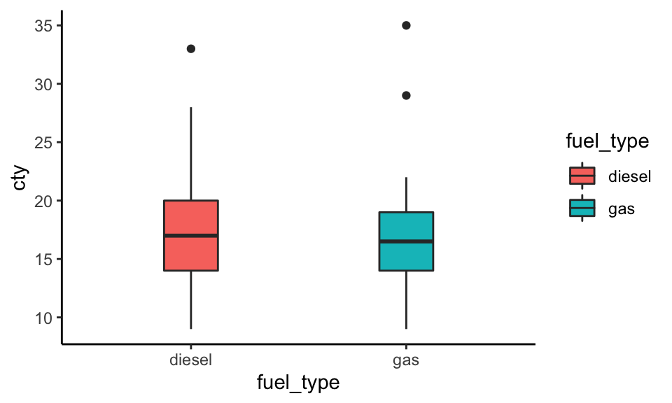

```r
ggplot(cty_by_fueltype) +
  geom_boxplot(aes(x = fuel_type, y=cty, fill = fuel_type), width = .25) +
  theme_classic()
```

## joining data

- joins merge together data frames by 1 or more ID columns, in this case `model`

## types of joins

- *_join( left, right, by..) - merge 2 data frames by common values in a shared column(s)
- `left_join`: keep all values in the left data frame. any values that are in the left, but not the right are kept, with NA values generated in the right df

```r
model2fuel[1:2, ] %>% left_join(mpg ,.) %>% filter(!grepl('a4',model)) %>% select(model, fuel_type)
```

```
## # A tibble: 219 × 2
##    model              fuel_type
##    <chr>              <chr>
##  1 a6 quattro         <NA>
##  2 a6 quattro         <NA>
##  3 a6 quattro         <NA>
##  4 c1500 suburban 2wd <NA>
##  5 c1500 suburban 2wd <NA>
##  6 c1500 suburban 2wd <NA>
##  7 c1500 suburban 2wd <NA>
##  8 c1500 suburban 2wd <NA>
##  9 corvette           <NA>
## 10 corvette           <NA>
## # … with 209 more rows
```

## types of joins

```r
model2fuel[1:2, ] %>% left_join(mpg) %>% select(model, fuel_type)
```

```
## # A tibble: 15 × 2
##    model      fuel_type
##    <chr>      <chr>
##  1 a4         gas
##  2 a4         gas
##  3 a4         gas
##  4 a4         gas
##  5 a4         gas
##  6 a4         gas
##  7 a4         gas
##  8 a4 quattro diesel
##  9 a4 quattro diesel
## 10 a4 quattro diesel
## # … with 5 more rows
```

## types of joins

- `inner_join` : only keep rows that have matching id’s in **both** columns; no NA’s will be generated, and if nothing matches an empty df is returned

```r
model2fuel[1:2, ] %>% inner_join(mpg,.) %>% select(model, fuel_type)
```

```
## # A tibble: 15 × 2
##    model      fuel_type
##    <chr>      <chr>
##  1 a4         gas
##  2 a4         gas
##  3 a4         gas
##  4 a4         gas
##  5 a4         gas
##  6 a4         gas
##  7 a4         gas
##  8 a4 quattro diesel
##  9 a4 quattro diesel
## 10 a4 quattro diesel
## # … with 5 more rows
```

## types of joins

- `full_join` joins all rows, as long as there is at least one common values between the join columns

```r
model2fuel[1:2, ] %>% full_join(mpg,.) %>% select(model, fuel_type)
```

```
## # A tibble: 234 × 2
##    model      fuel_type
##    <chr>      <chr>
##  1 a4         gas
##  2 a4         gas
##  3 a4         gas
##  4 a4         gas
##  5 a4         gas
##  6 a4         gas
##  7 a4         gas
##  8 a4 quattro diesel
##  9 a4 quattro diesel
## 10 a4 quattro diesel
## # … with 224 more rows
```

## duplicate values in joining columns

- be careful when joining columns that have repeated values in columns

```r
a4_only <- filter(mpg, model == 'a4')
dim(a4_only)
```

```
## [1]  7 11
```

```r
a4_fuel <- filter(model2fuel, model == 'a4') %>% bind_rows(. ,. ,. ,. ,. ,.)
dim(a4_fuel)
```

```
## [1] 6 2
```

## duplicate values in joining columns

```r
left_join(a4_only, a4_fuel, by= 'model') %>% dim
```

```
## [1] 42 12
```

- when you have duplicate values in joining columns in *both* data frames, the values will be matched multiple times
- if you’re not careful about this, you might make a data-frame that consumes all your memory and crashes R

## duplicate values in joining columns

- the `distinct` function will remove any duplicated rows, and help prevent this

```r
left_join(a4_only, a4_fuel %>% distinct, by= 'model') %>% dim
```

```
## [1]  7 12
```